# **Deep Learning in Stock Market Based on Long Short Term Memory Technique**

**Introduction**:

**Why LSTM?**

-LSTM is considered as an improvement of Reccurrent Neural Network which comes as a solution to vanishing

and exploding gradient, Bao et al(2017); Werbos et al. (1988); Schmidhuber et al. (1997);

-LSTM is suitable for sequences Sutskever et al. (2014);

-LSTM can store and retrieve information using its gates Bengio et al. (2009);

-LSTM doesn’t flow in a single way (unlike Neural Networks);

-LSTM technique can distinguish between recent and early examples Nelson et al. (2017).

**Data Exploration:**

The database used in this research contains New York Stock Exchange S&P500 data, publicly available at [Kaggle](https://www.kaggle.com/dgawlik/nyse), for the period between 04/01/2010 and 30/12/2016. It is splitted into 2 Datasets, one for prices : Open - Low - High - Close - Volume and daily indicators : MACD - Signal - RSI. The second Dataset contains 75 financial annual ratios that shows informations about the company itself. Data collected contains 417 companies.figure Stock Prices

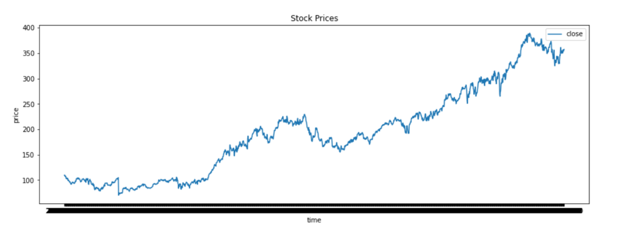

```python
from IPython.display import Image
Image(filename='2.png')
```

**Preprocessing Data:**

Before using Data as input for our Ensemble LSTM method, missing values are handled using Mean and Logistic regression functions in Python, then z-score normalization is applied.

**Methodology:**

Our model combines two feature categories in order to transmit the different aspects of an equity to the network. The first aspect considers historical daily stock price that reflects its trend. OHLC (Open, High, Low and Close stock prices), volume and trading indicators MACD, RSI and Signal show a share evolution based mainly on supply and demand. The second aspect consists of financial metrics that are part of the financial analysis. The objective is to take advantage of both technical analysis and fundamental-financial analysis. We can see an Ensemble LSTM approach as explained in the figure below.figure Ensemble LSTM approach

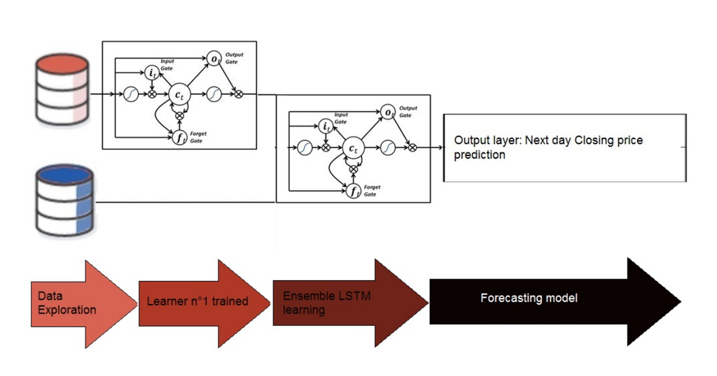

```python
from IPython.display import Image
Image(filename='1.png')
```

*Deep Learning Project*

*Autumn 2020*

*Mahdis Hosseini*